# Passenger Behaviour on Public Transport: Patterns of Phone Use and Bus Conditions

## Overview of Passenger Activities on Public Transport

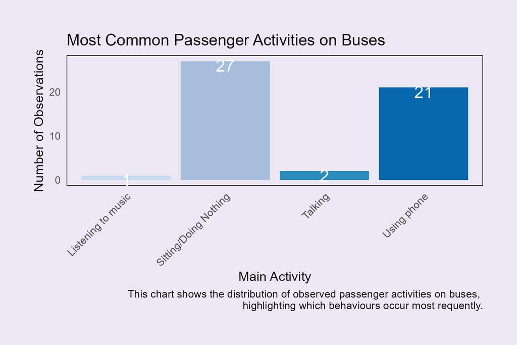

Bar chart showing passenger activities on buses, where sitting/doing nothing is the most common behaviour, followed by phone use and other activities such as talking or listening to music.

This bar chart shows how passenger activities are distributed on buses. The most common behaviour is sitting or doing nothing, which suggests that a large proportion of passengers are not actively engaged in any activity during their commute. The second most common activity is phone use, followed by smaller proportions of talking or listening to music. This pattern indicates that while sitting/doing nothing dominates overall, phone use is still a significant activity among passengers.

## Relationship Between Phone Use and Bus Occupancy

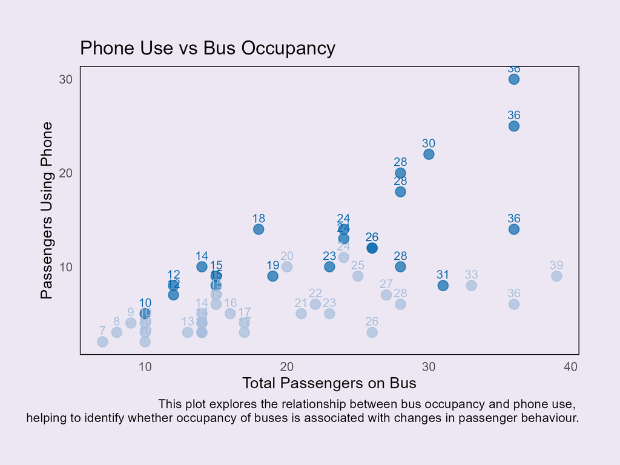

Scatter plot showing the relationship between total passengers on a bus and the number using phones, suggesting a possible association between bus occupancy and phone use.

The scatter plot examines the relationship between total bus occupancy and the number of passengers using phones. Higher bus occupancy levels may be associated with increased phone use. However, bus occupancy alone may not be a strong predictor of phone usage. Instead, phone use is likely influenced by a combination of factors, with occupancy playing a supporting role in shaping passenger behaviour.

## Changes in Phone Use Across the Day

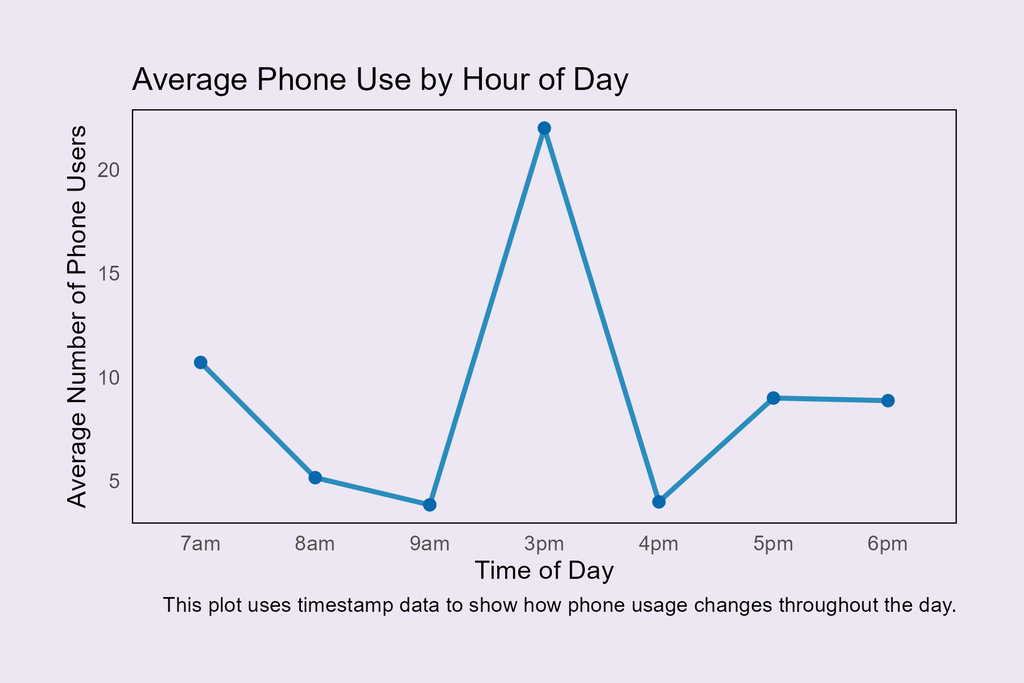

Line graph showing average phone use across different hours of the day, indicating temporal variation in behaviour over time.

Phone use varies across different hours of the day, showing fluctuations over time rather than remaining constant throughout the day. Certain periods show higher average phone use, which may correspond to peak travel times such as morning or afternoon commutes. This suggests that time of day plays a role in shaping passenger behaviour.

## Phone Use and Bus Crowdedness Levels

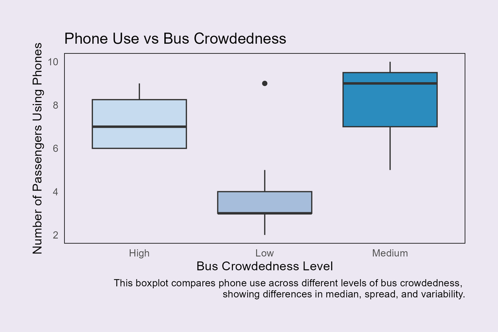

Boxplot comparing phone use across different levels of bus crowdedness, showing differences in median values and distribution between conditions.

This boxplot compares phone use across different levels of bus crowdedness. The results show differences in both the median and spread of phone use depending on crowdedness levels. The median for medium crowdedness is higher than for both low and high crowdedness levels. This may be because fewer passengers are present in low crowded buses, resulting in fewer observed phone users. In high crowdedness conditions, some passengers may be less able to use their phones due to limited space and the need to hold onto handrails for safety. Overall, this suggests that crowding may influence phone use on buses, although the relationship is not uniform across all levels.

## Morning Commute: Expectation vs Reality

[figure not shown]

Split image meme comparing expectation of productive morning commutes with reality of passengers scrolling on phones during travel, reflecting patterns of phone use during peak travel times.